# Risk Factor Analysis

## Outcome Variable

**Outcome Variable:** ever_stunted

## Predictor Variables

**Intervention Variable:** birthlen

**Adjustment Set:**

- arm
- W_mage
- meducyrs
- feducyrs
- vagbrth
- single
- brthmon
- W_parity
- delta_W_mage
- delta_meducyrs
- delta_feducyrs
- delta_vagbrth
- delta_single
- delta_brthmon
- delta_W_parity

## Stratifying Variables

The analysis was stratified on these variable(s):

- agecat
- studyid
- country

## Data Summary

| agecat | studyid | country | birthlen | ever_stunted | n_cell | n |
| --- | --- | --- | --- | --- | --- | --- |
| 0-24 months (no birth st.) | ki0047075b-MAL-ED | BANGLADESH | >=50 cm | 0 | 27 | 187 |
| 0-24 months (no birth st.) | ki0047075b-MAL-ED | BANGLADESH | >=50 cm | 1 | 12 | 187 |
| 0-24 months (no birth st.) | ki0047075b-MAL-ED | BANGLADESH | <48 cm | 0 | 24 | 187 |
| 0-24 months (no birth st.) | ki0047075b-MAL-ED | BANGLADESH | <48 cm | 1 | 45 | 187 |
| 0-24 months (no birth st.) | ki0047075b-MAL-ED | BANGLADESH | [48-50) cm | 0 | 37 | 187 |
| 0-24 months (no birth st.) | ki0047075b-MAL-ED | BANGLADESH | [48-50) cm | 1 | 42 | 187 |
| 0-24 months (no birth st.) | ki0047075b-MAL-ED | BRAZIL | >=50 cm | 0 | 30 | 56 |
| 0-24 months (no birth st.) | ki0047075b-MAL-ED | BRAZIL | >=50 cm | 1 | 0 | 56 |
| 0-24 months (no birth st.) | ki0047075b-MAL-ED | BRAZIL | <48 cm | 0 | 6 | 56 |
| 0-24 months (no birth st.) | ki0047075b-MAL-ED | BRAZIL | <48 cm | 1 | 2 | 56 |
| 0-24 months (no birth st.) | ki0047075b-MAL-ED | BRAZIL | [48-50) cm | 0 | 13 | 56 |
| 0-24 months (no birth st.) | ki0047075b-MAL-ED | BRAZIL | [48-50) cm | 1 | 5 | 56 |
| 0-24 months (no birth st.) | ki0047075b-MAL-ED | INDIA | >=50 cm | 0 | 8 | 37 |
| 0-24 months (no birth st.) | ki0047075b-MAL-ED | INDIA | >=50 cm | 1 | 1 | 37 |
| 0-24 months (no birth st.) | ki0047075b-MAL-ED | INDIA | <48 cm | 0 | 2 | 37 |
| 0-24 months (no birth st.) | ki0047075b-MAL-ED | INDIA | <48 cm | 1 | 8 | 37 |
| 0-24 months (no birth st.) | ki0047075b-MAL-ED | INDIA | [48-50) cm | 0 | 7 | 37 |
| 0-24 months (no birth st.) | ki0047075b-MAL-ED | INDIA | [48-50) cm | 1 | 11 | 37 |
| 0-24 months (no birth st.) | ki0047075b-MAL-ED | NEPAL | >=50 cm | 0 | 8 | 25 |
| 0-24 months (no birth st.) | ki0047075b-MAL-ED | NEPAL | >=50 cm | 1 | 0 | 25 |
| 0-24 months (no birth st.) | ki0047075b-MAL-ED | NEPAL | <48 cm | 0 | 5 | 25 |
| 0-24 months (no birth st.) | ki0047075b-MAL-ED | NEPAL | <48 cm | 1 | 5 | 25 |
| 0-24 months (no birth st.) | ki0047075b-MAL-ED | NEPAL | [48-50) cm | 0 | 3 | 25 |
| 0-24 months (no birth st.) | ki0047075b-MAL-ED | NEPAL | [48-50) cm | 1 | 4 | 25 |
| 0-24 months (no birth st.) | ki0047075b-MAL-ED | PERU | >=50 cm | 0 | 31 | 207 |
| 0-24 months (no birth st.) | ki0047075b-MAL-ED | PERU | >=50 cm | 1 | 21 | 207 |
| 0-24 months (no birth st.) | ki0047075b-MAL-ED | PERU | <48 cm | 0 | 15 | 207 |
| 0-24 months (no birth st.) | ki0047075b-MAL-ED | PERU | <48 cm | 1 | 47 | 207 |
| 0-24 months (no birth st.) | ki0047075b-MAL-ED | PERU | [48-50) cm | 0 | 45 | 207 |
| 0-24 months (no birth st.) | ki0047075b-MAL-ED | PERU | [48-50) cm | 1 | 48 | 207 |

[output cut: 438 more lines]

The following strata were considered:

- agecat: 0-24 months (no birth st.), studyid: ki0047075b-MAL-ED, country: BANGLADESH
- agecat: 0-24 months (no birth st.), studyid: ki0047075b-MAL-ED, country: BRAZIL
- agecat: 0-24 months (no birth st.), studyid: ki0047075b-MAL-ED, country: INDIA
- agecat: 0-24 months (no birth st.), studyid: ki0047075b-MAL-ED, country: NEPAL
- agecat: 0-24 months (no birth st.), studyid: ki0047075b-MAL-ED, country: PERU
- agecat: 0-24 months (no birth st.), studyid: ki0047075b-MAL-ED, country: SOUTH AFRICA
- agecat: 0-24 months (no birth st.), studyid: ki0047075b-MAL-ED, country: TANZANIA, UNITED REPUBLIC OF
- agecat: 0-24 months (no birth st.), studyid: ki1000108-CMC-V-BCS-2002, country: INDIA
- agecat: 0-24 months (no birth st.), studyid: ki1000108-IRC, country: INDIA
- agecat: 0-24 months (no birth st.), studyid: ki1000109-EE, country: PAKISTAN
- agecat: 0-24 months (no birth st.), studyid: ki1000109-ResPak, country: PAKISTAN
- agecat: 0-24 months (no birth st.), studyid: ki1000304b-SAS-CompFeed, country: INDIA
- agecat: 0-24 months (no birth st.), studyid: ki1017093-NIH-Birth, country: BANGLADESH
- agecat: 0-24 months (no birth st.), studyid: ki1017093b-PROVIDE, country: BANGLADESH
- agecat: 0-24 months (no birth st.), studyid: ki1017093c-NIH-Crypto, country: BANGLADESH
- agecat: 0-24 months (no birth st.), studyid: ki1101329-Keneba, country: GAMBIA
- agecat: 0-24 months (no birth st.), studyid: ki1113344-GMS-Nepal, country: NEPAL
- agecat: 0-24 months (no birth st.), studyid: ki1114097-CMIN, country: BANGLADESH
- agecat: 0-24 months (no birth st.), studyid: ki1114097-CONTENT, country: PERU
- agecat: 0-24 months (no birth st.), studyid: ki1119695-PROBIT, country: BELARUS
- agecat: 0-24 months (no birth st.), studyid: ki1126311-ZVITAMBO, country: ZIMBABWE
- agecat: 0-24 months (no birth st.), studyid: ki1135781-COHORTS, country: GUATEMALA
- agecat: 0-24 months (no birth st.), studyid: ki1135781-COHORTS, country: INDIA
- agecat: 0-24 months (no birth st.), studyid: ki1135781-COHORTS, country: PHILIPPINES
- agecat: 0-24 months (no birth st.), studyid: kiGH5241-JiVitA-3, country: BANGLADESH
- agecat: 0-24 months (no birth st.), studyid: kiGH5241-JiVitA-4, country: BANGLADESH
- agecat: 0-6 months (no birth st.), studyid: ki0047075b-MAL-ED, country: BANGLADESH
- agecat: 0-6 months (no birth st.), studyid: ki0047075b-MAL-ED, country: BRAZIL
- agecat: 0-6 months (no birth st.), studyid: ki0047075b-MAL-ED, country: INDIA
- agecat: 0-6 months (no birth st.), studyid: ki0047075b-MAL-ED, country: NEPAL
- agecat: 0-6 months (no birth st.), studyid: ki0047075b-MAL-ED, country: PERU
- agecat: 0-6 months (no birth st.), studyid: ki0047075b-MAL-ED, country: SOUTH AFRICA
- agecat: 0-6 months (no birth st.), studyid: ki0047075b-MAL-ED, country: TANZANIA, UNITED REPUBLIC OF
- agecat: 0-6 months (no birth st.), studyid: ki1000108-CMC-V-BCS-2002, country: INDIA
- agecat: 0-6 months (no birth st.), studyid: ki1000108-IRC, country: INDIA
- agecat: 0-6 months (no birth st.), studyid: ki1000109-EE, country: PAKISTAN
- agecat: 0-6 months (no birth st.), studyid: ki1000109-ResPak, country: PAKISTAN
- agecat: 0-6 months (no birth st.), studyid: ki1000304b-SAS-CompFeed, country: INDIA
- agecat: 0-6 months (no birth st.), studyid: ki1017093-NIH-Birth, country: BANGLADESH
- agecat: 0-6 months (no birth st.), studyid: ki1017093b-PROVIDE, country: BANGLADESH
- agecat: 0-6 months (no birth st.), studyid: ki1017093c-NIH-Crypto, country: BANGLADESH
- agecat: 0-6 months (no birth st.), studyid: ki1101329-Keneba, country: GAMBIA
- agecat: 0-6 months (no birth st.), studyid: ki1113344-GMS-Nepal, country: NEPAL
- agecat: 0-6 months (no birth st.), studyid: ki1114097-CMIN, country: BANGLADESH
- agecat: 0-6 months (no birth st.), studyid: ki1114097-CONTENT, country: PERU
- agecat: 0-6 months (no birth st.), studyid: ki1119695-PROBIT, country: BELARUS
- agecat: 0-6 months (no birth st.), studyid: ki1126311-ZVITAMBO, country: ZIMBABWE
- agecat: 0-6 months (no birth st.), studyid: ki1135781-COHORTS, country: GUATEMALA
- agecat: 0-6 months (no birth st.), studyid: ki1135781-COHORTS, country: INDIA
- agecat: 0-6 months (no birth st.), studyid: ki1135781-COHORTS, country: PHILIPPINES
- agecat: 0-6 months (no birth st.), studyid: kiGH5241-JiVitA-3, country: BANGLADESH
- agecat: 0-6 months (no birth st.), studyid: kiGH5241-JiVitA-4, country: BANGLADESH
- agecat: 6-24 months, studyid: ki0047075b-MAL-ED, country: BANGLADESH
- agecat: 6-24 months, studyid: ki0047075b-MAL-ED, country: BRAZIL
- agecat: 6-24 months, studyid: ki0047075b-MAL-ED, country: INDIA
- agecat: 6-24 months, studyid: ki0047075b-MAL-ED, country: NEPAL
- agecat: 6-24 months, studyid: ki0047075b-MAL-ED, country: PERU
- agecat: 6-24 months, studyid: ki0047075b-MAL-ED, country: SOUTH AFRICA
- agecat: 6-24 months, studyid: ki0047075b-MAL-ED, country: TANZANIA, UNITED REPUBLIC OF
- agecat: 6-24 months, studyid: ki1000108-CMC-V-BCS-2002, country: INDIA
- agecat: 6-24 months, studyid: ki1000108-IRC, country: INDIA
- agecat: 6-24 months, studyid: ki1000109-EE, country: PAKISTAN
- agecat: 6-24 months, studyid: ki1000109-ResPak, country: PAKISTAN
- agecat: 6-24 months, studyid: ki1000304b-SAS-CompFeed, country: INDIA
- agecat: 6-24 months, studyid: ki1017093-NIH-Birth, country: BANGLADESH
- agecat: 6-24 months, studyid: ki1017093b-PROVIDE, country: BANGLADESH
- agecat: 6-24 months, studyid: ki1017093c-NIH-Crypto, country: BANGLADESH
- agecat: 6-24 months, studyid: ki1101329-Keneba, country: GAMBIA
- agecat: 6-24 months, studyid: ki1113344-GMS-Nepal, country: NEPAL
- agecat: 6-24 months, studyid: ki1114097-CMIN, country: BANGLADESH
- agecat: 6-24 months, studyid: ki1114097-CONTENT, country: PERU
- agecat: 6-24 months, studyid: ki1119695-PROBIT, country: BELARUS
- agecat: 6-24 months, studyid: ki1126311-ZVITAMBO, country: ZIMBABWE
- agecat: 6-24 months, studyid: ki1135781-COHORTS, country: GUATEMALA
- agecat: 6-24 months, studyid: ki1135781-COHORTS, country: INDIA
- agecat: 6-24 months, studyid: ki1135781-COHORTS, country: PHILIPPINES
- agecat: 6-24 months, studyid: kiGH5241-JiVitA-3, country: BANGLADESH
- agecat: 6-24 months, studyid: kiGH5241-JiVitA-4, country: BANGLADESH

### Dropped Strata

Some strata were dropped due to rare outcomes:

- agecat: 0-24 months (no birth st.), studyid: ki0047075b-MAL-ED, country: BRAZIL
- agecat: 0-24 months (no birth st.), studyid: ki0047075b-MAL-ED, country: INDIA
- agecat: 0-24 months (no birth st.), studyid: ki0047075b-MAL-ED, country: NEPAL
- agecat: 0-24 months (no birth st.), studyid: ki0047075b-MAL-ED, country: TANZANIA, UNITED REPUBLIC OF
- agecat: 0-24 months (no birth st.), studyid: ki1000108-CMC-V-BCS-2002, country: INDIA
- agecat: 0-24 months (no birth st.), studyid: ki1000109-ResPak, country: PAKISTAN
- agecat: 0-24 months (no birth st.), studyid: ki1114097-CMIN, country: BANGLADESH
- agecat: 0-24 months (no birth st.), studyid: ki1114097-CONTENT, country: PERU
- agecat: 0-6 months (no birth st.), studyid: ki0047075b-MAL-ED, country: BANGLADESH
- agecat: 0-6 months (no birth st.), studyid: ki0047075b-MAL-ED, country: BRAZIL
- agecat: 0-6 months (no birth st.), studyid: ki0047075b-MAL-ED, country: INDIA
- agecat: 0-6 months (no birth st.), studyid: ki0047075b-MAL-ED, country: NEPAL
- agecat: 0-6 months (no birth st.), studyid: ki0047075b-MAL-ED, country: TANZANIA, UNITED REPUBLIC OF
- agecat: 0-6 months (no birth st.), studyid: ki1000109-EE, country: PAKISTAN
- agecat: 0-6 months (no birth st.), studyid: ki1000109-ResPak, country: PAKISTAN
- agecat: 0-6 months (no birth st.), studyid: ki1017093b-PROVIDE, country: BANGLADESH
- agecat: 0-6 months (no birth st.), studyid: ki1017093c-NIH-Crypto, country: BANGLADESH
- agecat: 0-6 months (no birth st.), studyid: ki1114097-CMIN, country: BANGLADESH
- agecat: 0-6 months (no birth st.), studyid: ki1114097-CONTENT, country: PERU
- agecat: 6-24 months, studyid: ki0047075b-MAL-ED, country: BRAZIL
- agecat: 6-24 months, studyid: ki0047075b-MAL-ED, country: INDIA
- agecat: 6-24 months, studyid: ki0047075b-MAL-ED, country: NEPAL
- agecat: 6-24 months, studyid: ki0047075b-MAL-ED, country: SOUTH AFRICA
- agecat: 6-24 months, studyid: ki0047075b-MAL-ED, country: TANZANIA, UNITED REPUBLIC OF
- agecat: 6-24 months, studyid: ki1000108-CMC-V-BCS-2002, country: INDIA
- agecat: 6-24 months, studyid: ki1000109-ResPak, country: PAKISTAN
- agecat: 6-24 months, studyid: ki1114097-CMIN, country: BANGLADESH
- agecat: 6-24 months, studyid: ki1114097-CONTENT, country: PERU

## Methods Detail

We’re interested in the causal parameters $E[Y_a]$ for all values of $a \in \mathcal{A}$. These parameters represent the mean outcome if, possibly contrary to fact, we intervened to set all units to have $A=a$. Under the randomization and positivity assumptions, these are identified by the statistical parameters $\psi_a=E_W[E_{Y|A,W}(Y|A=a,W)]$. In addition, we’re interested in the mean of $Y$, $E[Y]$ under no intervention (the observed mean). We will estimate these parameters by using SuperLearner to fit the relevant likelihood factors – $E_{Y|A,W}(Y|A=a,W)$ and $p(A=a|W)$, and then updating our likelihood fit using a joint TMLE.

For unadjusted analyses ($W=\{\}$), initial likelihoods were estimated using Lrnr_glm to estimate the simple $E(Y|A)$ and Lrnr_mean to estimate $p(A)$. For adjusted analyses, a small library containing Lrnr_glmnet, Lrnr_xgboost, and Lrnr_mean was used.

Having estimated these parameters, we will then use the delta method to estimate relative risks and attributable risks relative to a prespecified baseline level of $A$.

# Results Detail

## Results Plots

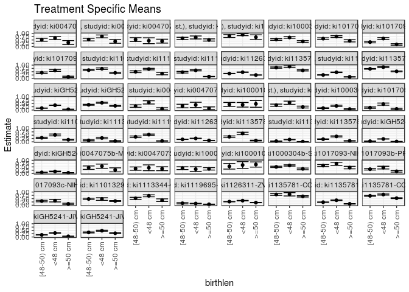

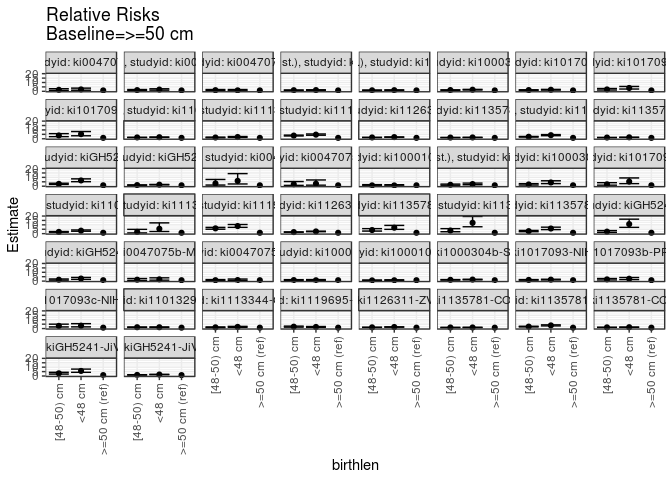

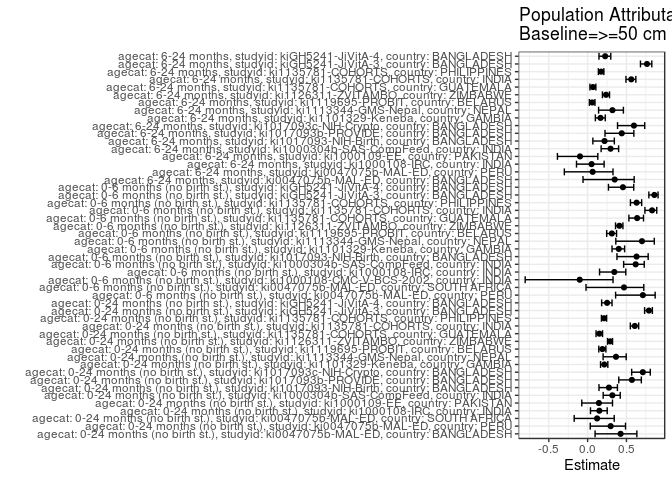

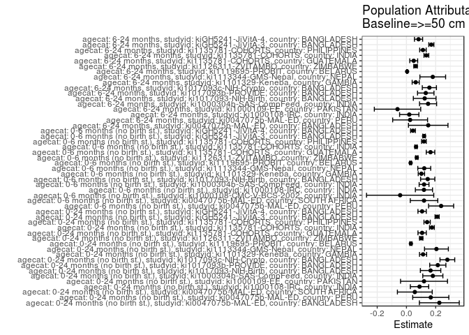

## Results Table

### Parameter: TSM

| agecat | studyid | country | intervention_level | baseline_level | estimate | ci_lower | ci_upper |
| --- | --- | --- | --- | --- | --- | --- | --- |
| 0-24 months (no birth st.) | ki0047075b-MAL-ED | BANGLADESH | >=50 cm | NA | 0.3044598 | 0.1547885 | 0.4541311 |
| 0-24 months (no birth st.) | ki0047075b-MAL-ED | BANGLADESH | <48 cm | NA | 0.6462883 | 0.5310448 | 0.7615318 |
| 0-24 months (no birth st.) | ki0047075b-MAL-ED | BANGLADESH | [48-50) cm | NA | 0.5177325 | 0.4069297 | 0.6285353 |
| 0-24 months (no birth st.) | ki0047075b-MAL-ED | PERU | >=50 cm | NA | 0.3939899 | 0.2531126 | 0.5348672 |
| 0-24 months (no birth st.) | ki0047075b-MAL-ED | PERU | <48 cm | NA | 0.7705297 | 0.6632358 | 0.8778236 |
| 0-24 months (no birth st.) | ki0047075b-MAL-ED | PERU | [48-50) cm | NA | 0.5309553 | 0.4308561 | 0.6310545 |
| 0-24 months (no birth st.) | ki0047075b-MAL-ED | SOUTH AFRICA | >=50 cm | NA | 0.4117796 | 0.2636171 | 0.5599422 |
| 0-24 months (no birth st.) | ki0047075b-MAL-ED | SOUTH AFRICA | <48 cm | NA | 0.4437843 | 0.2224060 | 0.6651627 |
| 0-24 months (no birth st.) | ki0047075b-MAL-ED | SOUTH AFRICA | [48-50) cm | NA | 0.5305073 | 0.3845191 | 0.6764956 |
| 0-24 months (no birth st.) | ki1000108-IRC | INDIA | >=50 cm | NA | 0.5018491 | 0.4189771 | 0.5847210 |
| 0-24 months (no birth st.) | ki1000108-IRC | INDIA | <48 cm | NA | 0.6909140 | 0.5771346 | 0.8046934 |
| 0-24 months (no birth st.) | ki1000108-IRC | INDIA | [48-50) cm | NA | 0.6224831 | 0.5410898 | 0.7038763 |
| 0-24 months (no birth st.) | ki1000109-EE | PAKISTAN | >=50 cm | NA | 0.7083333 | 0.5258340 | 0.8908327 |
| 0-24 months (no birth st.) | ki1000109-EE | PAKISTAN | <48 cm | NA | 0.9032258 | 0.8293696 | 0.9770820 |
| 0-24 months (no birth st.) | ki1000109-EE | PAKISTAN | [48-50) cm | NA | 0.7962963 | 0.6884899 | 0.9041027 |
| 0-24 months (no birth st.) | ki1000304b-SAS-CompFeed | INDIA | >=50 cm | NA | 0.3852466 | 0.3203236 | 0.4501696 |
| 0-24 months (no birth st.) | ki1000304b-SAS-CompFeed | INDIA | <48 cm | NA | 0.6897223 | 0.6299946 | 0.7494500 |
| 0-24 months (no birth st.) | ki1000304b-SAS-CompFeed | INDIA | [48-50) cm | NA | 0.5386179 | 0.4737854 | 0.6034504 |
| 0-24 months (no birth st.) | ki1017093-NIH-Birth | BANGLADESH | >=50 cm | NA | 0.4357162 | 0.3534001 | 0.5180324 |
| 0-24 months (no birth st.) | ki1017093-NIH-Birth | BANGLADESH | <48 cm | NA | 0.7576110 | 0.6871793 | 0.8280427 |
| 0-24 months (no birth st.) | ki1017093-NIH-Birth | BANGLADESH | [48-50) cm | NA | 0.6023162 | 0.5384408 | 0.6661916 |
| 0-24 months (no birth st.) | ki1017093b-PROVIDE | BANGLADESH | >=50 cm | NA | 0.1615229 | 0.1036386 | 0.2194072 |
| 0-24 months (no birth st.) | ki1017093b-PROVIDE | BANGLADESH | <48 cm | NA | 0.6076804 | 0.5362833 | 0.6790775 |
| 0-24 months (no birth st.) | ki1017093b-PROVIDE | BANGLADESH | [48-50) cm | NA | 0.3406467 | 0.2849131 | 0.3963802 |
| 0-24 months (no birth st.) | ki1017093c-NIH-Crypto | BANGLADESH | >=50 cm | NA | 0.1136832 | 0.0653715 | 0.1619949 |
| 0-24 months (no birth st.) | ki1017093c-NIH-Crypto | BANGLADESH | <48 cm | NA | 0.5995493 | 0.5286244 | 0.6704741 |
| 0-24 months (no birth st.) | ki1017093c-NIH-Crypto | BANGLADESH | [48-50) cm | NA | 0.4233991 | 0.3670970 | 0.4797012 |
| 0-24 months (no birth st.) | ki1101329-Keneba | GAMBIA | >=50 cm | NA | 0.4158547 | 0.3809760 | 0.4507335 |
| 0-24 months (no birth st.) | ki1101329-Keneba | GAMBIA | <48 cm | NA | 0.7262188 | 0.6651399 | 0.7872977 |
| 0-24 months (no birth st.) | ki1101329-Keneba | GAMBIA | [48-50) cm | NA | 0.6180820 | 0.5757159 | 0.6604480 |

[output cut: 120 more lines]

### Parameter: E(Y)

| agecat | studyid | country | intervention_level | baseline_level | estimate | ci_lower | ci_upper |
| --- | --- | --- | --- | --- | --- | --- | --- |
| 0-24 months (no birth st.) | ki0047075b-MAL-ED | BANGLADESH | NA | NA | 0.5294118 | 0.4576804 | 0.6011431 |
| 0-24 months (no birth st.) | ki0047075b-MAL-ED | PERU | NA | NA | 0.5603865 | 0.4926077 | 0.6281653 |
| 0-24 months (no birth st.) | ki0047075b-MAL-ED | SOUTH AFRICA | NA | NA | 0.4690265 | 0.3766048 | 0.5614483 |
| 0-24 months (no birth st.) | ki1000108-IRC | INDIA | NA | NA | 0.5913043 | 0.5393557 | 0.6432530 |
| 0-24 months (no birth st.) | ki1000109-EE | PAKISTAN | NA | NA | 0.8285714 | 0.7659176 | 0.8912252 |
| 0-24 months (no birth st.) | ki1000304b-SAS-CompFeed | INDIA | NA | NA | 0.5657407 | 0.5074689 | 0.6240126 |
| 0-24 months (no birth st.) | ki1017093-NIH-Birth | BANGLADESH | NA | NA | 0.6007828 | 0.5582791 | 0.6432864 |
| 0-24 months (no birth st.) | ki1017093b-PROVIDE | BANGLADESH | NA | NA | 0.3759874 | 0.3382238 | 0.4137509 |
| 0-24 months (no birth st.) | ki1017093c-NIH-Crypto | BANGLADESH | NA | NA | 0.3935681 | 0.3560687 | 0.4310676 |
| 0-24 months (no birth st.) | ki1101329-Keneba | GAMBIA | NA | NA | 0.5296120 | 0.5040796 | 0.5551444 |
| 0-24 months (no birth st.) | ki1113344-GMS-Nepal | NEPAL | NA | NA | 0.5617391 | 0.5211485 | 0.6023298 |
| 0-24 months (no birth st.) | ki1119695-PROBIT | BELARUS | NA | NA | 0.1597778 | 0.1408215 | 0.1787342 |
| 0-24 months (no birth st.) | ki1126311-ZVITAMBO | ZIMBABWE | NA | NA | 0.3494034 | 0.3410405 | 0.3577663 |
| 0-24 months (no birth st.) | ki1135781-COHORTS | GUATEMALA | NA | NA | 0.7082294 | 0.6767491 | 0.7397098 |
| 0-24 months (no birth st.) | ki1135781-COHORTS | INDIA | NA | NA | 0.2867647 | 0.2751726 | 0.2983568 |
| 0-24 months (no birth st.) | ki1135781-COHORTS | PHILIPPINES | NA | NA | 0.6671324 | 0.6498678 | 0.6843969 |
| 0-24 months (no birth st.) | kiGH5241-JiVitA-3 | BANGLADESH | NA | NA | 0.2656094 | 0.2573816 | 0.2738373 |
| 0-24 months (no birth st.) | kiGH5241-JiVitA-4 | BANGLADESH | NA | NA | 0.4273585 | 0.4069266 | 0.4477904 |
| 0-6 months (no birth st.) | ki0047075b-MAL-ED | PERU | NA | NA | 0.3333333 | 0.2689597 | 0.3977070 |
| 0-6 months (no birth st.) | ki0047075b-MAL-ED | SOUTH AFRICA | NA | NA | 0.2566372 | 0.1757463 | 0.3375280 |
| 0-6 months (no birth st.) | ki1000108-CMC-V-BCS-2002 | INDIA | NA | NA | 0.4235294 | 0.3178625 | 0.5291963 |
| 0-6 months (no birth st.) | ki1000108-IRC | INDIA | NA | NA | 0.3478261 | 0.2974955 | 0.3981566 |
| 0-6 months (no birth st.) | ki1000304b-SAS-CompFeed | INDIA | NA | NA | 0.1946247 | 0.1703263 | 0.2189230 |
| 0-6 months (no birth st.) | ki1017093-NIH-Birth | BANGLADESH | NA | NA | 0.2309198 | 0.1943452 | 0.2674943 |
| 0-6 months (no birth st.) | ki1101329-Keneba | GAMBIA | NA | NA | 0.2552757 | 0.2329715 | 0.2775799 |
| 0-6 months (no birth st.) | ki1113344-GMS-Nepal | NEPAL | NA | NA | 0.1739130 | 0.1429052 | 0.2049209 |
| 0-6 months (no birth st.) | ki1119695-PROBIT | BELARUS | NA | NA | 0.0912784 | 0.0781588 | 0.1043979 |
| 0-6 months (no birth st.) | ki1126311-ZVITAMBO | ZIMBABWE | NA | NA | 0.1729137 | 0.1662801 | 0.1795472 |
| 0-6 months (no birth st.) | ki1135781-COHORTS | GUATEMALA | NA | NA | 0.2581047 | 0.2278007 | 0.2884088 |
| 0-6 months (no birth st.) | ki1135781-COHORTS | INDIA | NA | NA | 0.0790014 | 0.0720874 | 0.0859154 |
| 0-6 months (no birth st.) | ki1135781-COHORTS | PHILIPPINES | NA | NA | 0.1893119 | 0.1749594 | 0.2036645 |
| 0-6 months (no birth st.) | kiGH5241-JiVitA-3 | BANGLADESH | NA | NA | 0.1402030 | 0.1340165 | 0.1463895 |
| 0-6 months (no birth st.) | kiGH5241-JiVitA-4 | BANGLADESH | NA | NA | 0.0984277 | 0.0855770 | 0.1112784 |
| 6-24 months | ki0047075b-MAL-ED | BANGLADESH | NA | NA | 0.4275362 | 0.3446947 | 0.5103778 |
| 6-24 months | ki0047075b-MAL-ED | PERU | NA | NA | 0.3884298 | 0.3012257 | 0.4756338 |
| 6-24 months | ki1000108-IRC | INDIA | NA | NA | 0.3733333 | 0.3099915 | 0.4366752 |
| 6-24 months | ki1000109-EE | PAKISTAN | NA | NA | 0.6206897 | 0.4947260 | 0.7466533 |
| 6-24 months | ki1000304b-SAS-CompFeed | INDIA | NA | NA | 0.5006242 | 0.4555100 | 0.5457384 |
| 6-24 months | ki1017093-NIH-Birth | BANGLADESH | NA | NA | 0.5727273 | 0.5192737 | 0.6261808 |
| 6-24 months | ki1017093b-PROVIDE | BANGLADESH | NA | NA | 0.3004386 | 0.2583143 | 0.3425629 |
| 6-24 months | ki1017093c-NIH-Crypto | BANGLADESH | NA | NA | 0.2628458 | 0.2244546 | 0.3012371 |
| 6-24 months | ki1101329-Keneba | GAMBIA | NA | NA | 0.3816288 | 0.3523153 | 0.4109422 |
| 6-24 months | ki1113344-GMS-Nepal | NEPAL | NA | NA | 0.5631313 | 0.5142177 | 0.6120449 |
| 6-24 months | ki1119695-PROBIT | BELARUS | NA | NA | 0.0768510 | 0.0628857 | 0.0908164 |
| 6-24 months | ki1126311-ZVITAMBO | ZIMBABWE | NA | NA | 0.2627189 | 0.2533027 | 0.2721352 |
| 6-24 months | ki1135781-COHORTS | GUATEMALA | NA | NA | 0.7234469 | 0.6841620 | 0.7627318 |
| 6-24 months | ki1135781-COHORTS | INDIA | NA | NA | 0.2424242 | 0.2305635 | 0.2542850 |
| 6-24 months | ki1135781-COHORTS | PHILIPPINES | NA | NA | 0.6465028 | 0.6261291 | 0.6668766 |
| 6-24 months | kiGH5241-JiVitA-3 | BANGLADESH | NA | NA | 0.2226530 | 0.2124032 | 0.2329029 |
| 6-24 months | kiGH5241-JiVitA-4 | BANGLADESH | NA | NA | 0.3663989 | 0.3454886 | 0.3873091 |

### Parameter: RR

| agecat | studyid | country | intervention_level | baseline_level | estimate | ci_lower | ci_upper |
| --- | --- | --- | --- | --- | --- | --- | --- |
| 0-24 months (no birth st.) | ki0047075b-MAL-ED | BANGLADESH | >=50 cm | >=50 cm | 1.0000000 | 1.0000000 | 1.000000 |
| 0-24 months (no birth st.) | ki0047075b-MAL-ED | BANGLADESH | <48 cm | >=50 cm | 2.1227376 | 1.2564731 | 3.586241 |
| 0-24 months (no birth st.) | ki0047075b-MAL-ED | BANGLADESH | [48-50) cm | >=50 cm | 1.7004954 | 0.9943651 | 2.908071 |
| 0-24 months (no birth st.) | ki0047075b-MAL-ED | PERU | >=50 cm | >=50 cm | 1.0000000 | 1.0000000 | 1.000000 |
| 0-24 months (no birth st.) | ki0047075b-MAL-ED | PERU | <48 cm | >=50 cm | 1.9557094 | 1.3317235 | 2.872067 |
| 0-24 months (no birth st.) | ki0047075b-MAL-ED | PERU | [48-50) cm | >=50 cm | 1.3476370 | 0.8997627 | 2.018449 |
| 0-24 months (no birth st.) | ki0047075b-MAL-ED | SOUTH AFRICA | >=50 cm | >=50 cm | 1.0000000 | 1.0000000 | 1.000000 |
| 0-24 months (no birth st.) | ki0047075b-MAL-ED | SOUTH AFRICA | <48 cm | >=50 cm | 1.0777229 | 0.5815066 | 1.997375 |
| 0-24 months (no birth st.) | ki0047075b-MAL-ED | SOUTH AFRICA | [48-50) cm | >=50 cm | 1.2883283 | 0.8153674 | 2.035634 |
| 0-24 months (no birth st.) | ki1000108-IRC | INDIA | >=50 cm | >=50 cm | 1.0000000 | 1.0000000 | 1.000000 |
| 0-24 months (no birth st.) | ki1000108-IRC | INDIA | <48 cm | >=50 cm | 1.3767366 | 1.0911041 | 1.737143 |
| 0-24 months (no birth st.) | ki1000108-IRC | INDIA | [48-50) cm | >=50 cm | 1.2403790 | 1.0050907 | 1.530747 |
| 0-24 months (no birth st.) | ki1000109-EE | PAKISTAN | >=50 cm | >=50 cm | 1.0000000 | 1.0000000 | 1.000000 |
| 0-24 months (no birth st.) | ki1000109-EE | PAKISTAN | <48 cm | >=50 cm | 1.2751423 | 0.9731153 | 1.670910 |
| 0-24 months (no birth st.) | ki1000109-EE | PAKISTAN | [48-50) cm | >=50 cm | 1.1241830 | 0.8403017 | 1.503969 |
| 0-24 months (no birth st.) | ki1000304b-SAS-CompFeed | INDIA | >=50 cm | >=50 cm | 1.0000000 | 1.0000000 | 1.000000 |
| 0-24 months (no birth st.) | ki1000304b-SAS-CompFeed | INDIA | <48 cm | >=50 cm | 1.7903397 | 1.4872876 | 2.155142 |
| 0-24 months (no birth st.) | ki1000304b-SAS-CompFeed | INDIA | [48-50) cm | >=50 cm | 1.3981121 | 1.1750065 | 1.663580 |
| 0-24 months (no birth st.) | ki1017093-NIH-Birth | BANGLADESH | >=50 cm | >=50 cm | 1.0000000 | 1.0000000 | 1.000000 |
| 0-24 months (no birth st.) | ki1017093-NIH-Birth | BANGLADESH | <48 cm | >=50 cm | 1.7387716 | 1.4090192 | 2.145696 |
| 0-24 months (no birth st.) | ki1017093-NIH-Birth | BANGLADESH | [48-50) cm | >=50 cm | 1.3823590 | 1.1131242 | 1.716714 |
| 0-24 months (no birth st.) | ki1017093b-PROVIDE | BANGLADESH | >=50 cm | >=50 cm | 1.0000000 | 1.0000000 | 1.000000 |
| 0-24 months (no birth st.) | ki1017093b-PROVIDE | BANGLADESH | <48 cm | >=50 cm | 3.7621938 | 2.5785897 | 5.489087 |
| 0-24 months (no birth st.) | ki1017093b-PROVIDE | BANGLADESH | [48-50) cm | >=50 cm | 2.1089685 | 1.4209442 | 3.130136 |
| 0-24 months (no birth st.) | ki1017093c-NIH-Crypto | BANGLADESH | >=50 cm | >=50 cm | 1.0000000 | 1.0000000 | 1.000000 |
| 0-24 months (no birth st.) | ki1017093c-NIH-Crypto | BANGLADESH | <48 cm | >=50 cm | 5.2738599 | 3.3927183 | 8.198028 |
| 0-24 months (no birth st.) | ki1017093c-NIH-Crypto | BANGLADESH | [48-50) cm | >=50 cm | 3.7243769 | 2.3868975 | 5.811303 |
| 0-24 months (no birth st.) | ki1101329-Keneba | GAMBIA | >=50 cm | >=50 cm | 1.0000000 | 1.0000000 | 1.000000 |
| 0-24 months (no birth st.) | ki1101329-Keneba | GAMBIA | <48 cm | >=50 cm | 1.7463280 | 1.5515003 | 1.965621 |
| 0-24 months (no birth st.) | ki1101329-Keneba | GAMBIA | [48-50) cm | >=50 cm | 1.4862929 | 1.3348820 | 1.654878 |

[output cut: 120 more lines]

### Parameter: PAR

| agecat | studyid | country | intervention_level | baseline_level | estimate | ci_lower | ci_upper |
| --- | --- | --- | --- | --- | --- | --- | --- |
| 0-24 months (no birth st.) | ki0047075b-MAL-ED | BANGLADESH | >=50 cm | NA | 0.2249520 | 0.0885596 | 0.3613443 |
| 0-24 months (no birth st.) | ki0047075b-MAL-ED | PERU | >=50 cm | NA | 0.1663966 | 0.0428757 | 0.2899175 |
| 0-24 months (no birth st.) | ki0047075b-MAL-ED | SOUTH AFRICA | >=50 cm | NA | 0.0572469 | -0.0619325 | 0.1764264 |
| 0-24 months (no birth st.) | ki1000108-IRC | INDIA | >=50 cm | NA | 0.0894553 | 0.0266952 | 0.1522153 |
| 0-24 months (no birth st.) | ki1000109-EE | PAKISTAN | >=50 cm | NA | 0.1202381 | -0.0404240 | 0.2809002 |
| 0-24 months (no birth st.) | ki1000304b-SAS-CompFeed | INDIA | >=50 cm | NA | 0.1804942 | 0.1116845 | 0.2493039 |
| 0-24 months (no birth st.) | ki1017093-NIH-Birth | BANGLADESH | >=50 cm | NA | 0.1650666 | 0.0952019 | 0.2349312 |
| 0-24 months (no birth st.) | ki1017093b-PROVIDE | BANGLADESH | >=50 cm | NA | 0.2144645 | 0.1591641 | 0.2697648 |
| 0-24 months (no birth st.) | ki1017093c-NIH-Crypto | BANGLADESH | >=50 cm | NA | 0.2798849 | 0.2294012 | 0.3303687 |
| 0-24 months (no birth st.) | ki1101329-Keneba | GAMBIA | >=50 cm | NA | 0.1137572 | 0.0894408 | 0.1380737 |
| 0-24 months (no birth st.) | ki1113344-GMS-Nepal | NEPAL | >=50 cm | NA | 0.2051442 | 0.1235821 | 0.2867062 |
| 0-24 months (no birth st.) | ki1119695-PROBIT | BELARUS | >=50 cm | NA | 0.0304979 | 0.0234498 | 0.0375460 |
| 0-24 months (no birth st.) | ki1126311-ZVITAMBO | ZIMBABWE | >=50 cm | NA | 0.1011016 | 0.0897505 | 0.1124527 |
| 0-24 months (no birth st.) | ki1135781-COHORTS | GUATEMALA | >=50 cm | NA | 0.1073298 | 0.0788188 | 0.1358409 |
| 0-24 months (no birth st.) | ki1135781-COHORTS | INDIA | >=50 cm | NA | 0.1741960 | 0.1577919 | 0.1906000 |
| 0-24 months (no birth st.) | ki1135781-COHORTS | PHILIPPINES | >=50 cm | NA | 0.1414001 | 0.1198506 | 0.1629495 |
| 0-24 months (no birth st.) | kiGH5241-JiVitA-3 | BANGLADESH | >=50 cm | NA | 0.2097755 | 0.1957471 | 0.2238039 |
| 0-24 months (no birth st.) | kiGH5241-JiVitA-4 | BANGLADESH | >=50 cm | NA | 0.1070393 | 0.0786025 | 0.1354760 |
| 0-6 months (no birth st.) | ki0047075b-MAL-ED | PERU | >=50 cm | NA | 0.2371795 | 0.1514234 | 0.3229356 |
| 0-6 months (no birth st.) | ki0047075b-MAL-ED | SOUTH AFRICA | >=50 cm | NA | 0.1202735 | 0.0262608 | 0.2142862 |
| 0-6 months (no birth st.) | ki1000108-CMC-V-BCS-2002 | INDIA | >=50 cm | NA | -0.0431373 | -0.2731369 | 0.1868624 |
| 0-6 months (no birth st.) | ki1000108-IRC | INDIA | >=50 cm | NA | 0.1197185 | 0.0610390 | 0.1783980 |
| 0-6 months (no birth st.) | ki1000304b-SAS-CompFeed | INDIA | >=50 cm | NA | 0.1204686 | 0.0868480 | 0.1540892 |
| 0-6 months (no birth st.) | ki1017093-NIH-Birth | BANGLADESH | >=50 cm | NA | 0.1454592 | 0.0967949 | 0.1941236 |
| 0-6 months (no birth st.) | ki1101329-Keneba | GAMBIA | >=50 cm | NA | 0.1023333 | 0.0806487 | 0.1240179 |
| 0-6 months (no birth st.) | ki1113344-GMS-Nepal | NEPAL | >=50 cm | NA | 0.1217391 | 0.0775312 | 0.1659471 |
| 0-6 months (no birth st.) | ki1119695-PROBIT | BELARUS | >=50 cm | NA | 0.0284774 | 0.0225094 | 0.0344453 |
| 0-6 months (no birth st.) | ki1126311-ZVITAMBO | ZIMBABWE | >=50 cm | NA | 0.0707373 | 0.0621863 | 0.0792883 |
| 0-6 months (no birth st.) | ki1135781-COHORTS | GUATEMALA | >=50 cm | NA | 0.1646221 | 0.1354901 | 0.1937541 |
| 0-6 months (no birth st.) | ki1135781-COHORTS | INDIA | >=50 cm | NA | 0.0656015 | 0.0574746 | 0.0737285 |
| 0-6 months (no birth st.) | ki1135781-COHORTS | PHILIPPINES | >=50 cm | NA | 0.1194217 | 0.1035310 | 0.1353123 |
| 0-6 months (no birth st.) | kiGH5241-JiVitA-3 | BANGLADESH | >=50 cm | NA | 0.1205680 | 0.1114821 | 0.1296540 |
| 0-6 months (no birth st.) | kiGH5241-JiVitA-4 | BANGLADESH | >=50 cm | NA | 0.0447659 | 0.0284727 | 0.0610591 |
| 6-24 months | ki0047075b-MAL-ED | BANGLADESH | >=50 cm | NA | 0.1490177 | 0.0138737 | 0.2841616 |
| 6-24 months | ki0047075b-MAL-ED | PERU | >=50 cm | NA | 0.0250974 | -0.0942379 | 0.1444327 |
| 6-24 months | ki1000108-IRC | INDIA | >=50 cm | NA | 0.0190708 | -0.0469123 | 0.0850539 |
| 6-24 months | ki1000109-EE | PAKISTAN | >=50 cm | NA | -0.0611285 | -0.2197818 | 0.0975248 |
| 6-24 months | ki1000304b-SAS-CompFeed | INDIA | >=50 cm | NA | 0.1479791 | 0.0896063 | 0.2063519 |
| 6-24 months | ki1017093-NIH-Birth | BANGLADESH | >=50 cm | NA | 0.1247805 | 0.0470824 | 0.2024785 |
| 6-24 months | ki1017093b-PROVIDE | BANGLADESH | >=50 cm | NA | 0.1320735 | 0.0758082 | 0.1883387 |
| 6-24 months | ki1017093c-NIH-Crypto | BANGLADESH | >=50 cm | NA | 0.1568520 | 0.1085321 | 0.2051719 |
| 6-24 months | ki1101329-Keneba | GAMBIA | >=50 cm | NA | 0.0633024 | 0.0390707 | 0.0875341 |
| 6-24 months | ki1113344-GMS-Nepal | NEPAL | >=50 cm | NA | 0.1799678 | 0.0919713 | 0.2679642 |
| 6-24 months | ki1119695-PROBIT | BELARUS | >=50 cm | NA | 0.0045550 | 0.0017845 | 0.0073256 |
| 6-24 months | ki1126311-ZVITAMBO | ZIMBABWE | >=50 cm | NA | 0.0624543 | 0.0503696 | 0.0745391 |
| 6-24 months | ki1135781-COHORTS | GUATEMALA | >=50 cm | NA | 0.0496664 | 0.0226156 | 0.0767172 |
| 6-24 months | ki1135781-COHORTS | INDIA | >=50 cm | NA | 0.1362681 | 0.1198838 | 0.1526523 |
| 6-24 months | ki1135781-COHORTS | PHILIPPINES | >=50 cm | NA | 0.1128215 | 0.0905969 | 0.1350462 |
| 6-24 months | kiGH5241-JiVitA-3 | BANGLADESH | >=50 cm | NA | 0.1702722 | 0.1529012 | 0.1876433 |
| 6-24 months | kiGH5241-JiVitA-4 | BANGLADESH | >=50 cm | NA | 0.0827802 | 0.0548957 | 0.1106647 |

### Parameter: PAF

| agecat | studyid | country | intervention_level | baseline_level | estimate | ci_lower | ci_upper |
| --- | --- | --- | --- | --- | --- | --- | --- |
| 0-24 months (no birth st.) | ki0047075b-MAL-ED | BANGLADESH | >=50 cm | NA | 0.4249092 | 0.0960407 | 0.6341324 |
| 0-24 months (no birth st.) | ki0047075b-MAL-ED | PERU | >=50 cm | NA | 0.2969319 | 0.0340752 | 0.4882575 |
| 0-24 months (no birth st.) | ki0047075b-MAL-ED | SOUTH AFRICA | >=50 cm | NA | 0.1220548 | -0.1729992 | 0.3428915 |
| 0-24 months (no birth st.) | ki1000108-IRC | INDIA | >=50 cm | NA | 0.1512847 | 0.0367570 | 0.2521952 |
| 0-24 months (no birth st.) | ki1000109-EE | PAKISTAN | >=50 cm | NA | 0.1451149 | -0.0753561 | 0.3203847 |
| 0-24 months (no birth st.) | ki1000304b-SAS-CompFeed | INDIA | >=50 cm | NA | 0.3190404 | 0.2003522 | 0.4201123 |
| 0-24 months (no birth st.) | ki1017093-NIH-Birth | BANGLADESH | >=50 cm | NA | 0.2747525 | 0.1463898 | 0.3838124 |
| 0-24 months (no birth st.) | ki1017093b-PROVIDE | BANGLADESH | >=50 cm | NA | 0.5704034 | 0.4012557 | 0.6917662 |
| 0-24 months (no birth st.) | ki1017093c-NIH-Crypto | BANGLADESH | >=50 cm | NA | 0.7111474 | 0.5674479 | 0.8071080 |
| 0-24 months (no birth st.) | ki1101329-Keneba | GAMBIA | >=50 cm | NA | 0.2147935 | 0.1665182 | 0.2602728 |
| 0-24 months (no birth st.) | ki1113344-GMS-Nepal | NEPAL | >=50 cm | NA | 0.3651947 | 0.1993578 | 0.4966818 |
| 0-24 months (no birth st.) | ki1119695-PROBIT | BELARUS | >=50 cm | NA | 0.1908769 | 0.1438942 | 0.2352811 |
| 0-24 months (no birth st.) | ki1126311-ZVITAMBO | ZIMBABWE | >=50 cm | NA | 0.2893549 | 0.2562830 | 0.3209562 |
| 0-24 months (no birth st.) | ki1135781-COHORTS | GUATEMALA | >=50 cm | NA | 0.1515467 | 0.1084996 | 0.1925153 |
| 0-24 months (no birth st.) | ki1135781-COHORTS | INDIA | >=50 cm | NA | 0.6074527 | 0.5501432 | 0.6574612 |
| 0-24 months (no birth st.) | ki1135781-COHORTS | PHILIPPINES | >=50 cm | NA | 0.2119520 | 0.1779668 | 0.2445321 |
| 0-24 months (no birth st.) | kiGH5241-JiVitA-3 | BANGLADESH | >=50 cm | NA | 0.7897893 | 0.7338762 | 0.8339550 |
| 0-24 months (no birth st.) | kiGH5241-JiVitA-4 | BANGLADESH | >=50 cm | NA | 0.2504672 | 0.1807520 | 0.3142498 |
| 0-6 months (no birth st.) | ki0047075b-MAL-ED | PERU | >=50 cm | NA | 0.7115385 | 0.3604435 | 0.8698941 |
| 0-6 months (no birth st.) | ki0047075b-MAL-ED | SOUTH AFRICA | >=50 cm | NA | 0.4686520 | -0.0208523 | 0.7234363 |
| 0-6 months (no birth st.) | ki1000108-CMC-V-BCS-2002 | INDIA | >=50 cm | NA | -0.1018519 | -0.8043179 | 0.3271266 |
| 0-6 months (no birth st.) | ki1000108-IRC | INDIA | >=50 cm | NA | 0.3441907 | 0.1537417 | 0.4917794 |
| 0-6 months (no birth st.) | ki1000304b-SAS-CompFeed | INDIA | >=50 cm | NA | 0.6189793 | 0.4640030 | 0.7291463 |
| 0-6 months (no birth st.) | ki1017093-NIH-Birth | BANGLADESH | >=50 cm | NA | 0.6299124 | 0.3777937 | 0.7798723 |
| 0-6 months (no birth st.) | ki1101329-Keneba | GAMBIA | >=50 cm | NA | 0.4008736 | 0.3143602 | 0.4764709 |
| 0-6 months (no birth st.) | ki1113344-GMS-Nepal | NEPAL | >=50 cm | NA | 0.7000000 | 0.3631065 | 0.8586891 |
| 0-6 months (no birth st.) | ki1119695-PROBIT | BELARUS | >=50 cm | NA | 0.3119838 | 0.2454317 | 0.3726660 |
| 0-6 months (no birth st.) | ki1126311-ZVITAMBO | ZIMBABWE | >=50 cm | NA | 0.4090901 | 0.3595704 | 0.4547809 |
| 0-6 months (no birth st.) | ki1135781-COHORTS | GUATEMALA | >=50 cm | NA | 0.6378112 | 0.5316848 | 0.7198880 |
| 0-6 months (no birth st.) | ki1135781-COHORTS | INDIA | >=50 cm | NA | 0.8303849 | 0.7377815 | 0.8902850 |
| 0-6 months (no birth st.) | ki1135781-COHORTS | PHILIPPINES | >=50 cm | NA | 0.6308196 | 0.5513746 | 0.6961960 |
| 0-6 months (no birth st.) | kiGH5241-JiVitA-3 | BANGLADESH | >=50 cm | NA | 0.8599530 | 0.7887607 | 0.9071520 |
| 0-6 months (no birth st.) | kiGH5241-JiVitA-4 | BANGLADESH | >=50 cm | NA | 0.4548099 | 0.2681693 | 0.5938511 |
| 6-24 months | ki0047075b-MAL-ED | BANGLADESH | >=50 cm | NA | 0.3485498 | -0.0593874 | 0.5994030 |
| 6-24 months | ki0047075b-MAL-ED | PERU | >=50 cm | NA | 0.0646124 | -0.2998368 | 0.3268771 |
| 6-24 months | ki1000108-IRC | INDIA | >=50 cm | NA | 0.0510825 | -0.1432845 | 0.2124057 |
| 6-24 months | ki1000109-EE | PAKISTAN | >=50 cm | NA | -0.0984848 | -0.3888305 | 0.1311618 |
| 6-24 months | ki1000304b-SAS-CompFeed | INDIA | >=50 cm | NA | 0.2955892 | 0.1740374 | 0.3992530 |
| 6-24 months | ki1017093-NIH-Birth | BANGLADESH | >=50 cm | NA | 0.2178707 | 0.0674672 | 0.3440164 |
| 6-24 months | ki1017093b-PROVIDE | BANGLADESH | >=50 cm | NA | 0.4396022 | 0.2238227 | 0.5953944 |
| 6-24 months | ki1017093c-NIH-Crypto | BANGLADESH | >=50 cm | NA | 0.5967453 | 0.3852056 | 0.7354979 |
| 6-24 months | ki1101329-Keneba | GAMBIA | >=50 cm | NA | 0.1658742 | 0.0996599 | 0.2272189 |
| 6-24 months | ki1113344-GMS-Nepal | NEPAL | >=50 cm | NA | 0.3195840 | 0.1413181 | 0.4608412 |
| 6-24 months | ki1119695-PROBIT | BELARUS | >=50 cm | NA | 0.0592711 | 0.0229256 | 0.0942645 |
| 6-24 months | ki1126311-ZVITAMBO | ZIMBABWE | >=50 cm | NA | 0.2377229 | 0.1906904 | 0.2820222 |
| 6-24 months | ki1135781-COHORTS | GUATEMALA | >=50 cm | NA | 0.0686525 | 0.0297578 | 0.1059879 |
| 6-24 months | ki1135781-COHORTS | INDIA | >=50 cm | NA | 0.5621058 | 0.4938128 | 0.6211849 |
| 6-24 months | ki1135781-COHORTS | PHILIPPINES | >=50 cm | NA | 0.1745105 | 0.1384921 | 0.2090230 |
| 6-24 months | kiGH5241-JiVitA-3 | BANGLADESH | >=50 cm | NA | 0.7647424 | 0.6807007 | 0.8266638 |
| 6-24 months | kiGH5241-JiVitA-4 | BANGLADESH | >=50 cm | NA | 0.2259292 | 0.1463601 | 0.2980815 |